# 회귀기말대비(Ch9)

doellomdoel

2024-06-10

## 0. 데이터 로드 powercell

```r
tab9.1<-read.table("http://www.stat.ufl.edu/~rrandles/sta4210/Rclassnotes/data/textdatasets/KutnerData/Chapter%20%209%20Data%20Sets/CH09TA01.txt")
names(tab9.1)<-c("X1","X2","X3","X4","X5","X6","X7","X8","Y","logY")

head(tab9.1)
```

```
##    X1 X2  X3   X4 X5 X6 X7 X8    Y  logY
## 1 6.7 62  81 2.59 50  0  1  0  695 6.544
## 2 5.1 59  66 1.70 39  0  0  0  403 5.999
## 3 7.4 57  83 2.16 55  0  0  0  710 6.565
## 4 6.5 73  41 2.01 48  0  0  0  349 5.854
## 5 7.8 65 115 4.30 45  0  0  1 2343 7.759
## 6 5.8 38  72 1.42 65  1  1  0  348 5.852
```

```r
tail(tab9.1)
```

```
##     X1 X2  X3   X4 X5 X6 X7 X8    Y  logY
## 49 5.1 67  77 2.86 66  1  0  0  581 6.365
## 50 3.9 82 103 4.55 50  0  1  0 1078 6.983
## 51 6.6 77  46 1.95 50  0  1  0  405 6.005
## 52 6.4 85  40 1.21 58  0  0  1  579 6.361
## 53 6.4 59  85 2.33 63  0  1  0  550 6.310
## 54 8.8 78  72 3.20 56  0  0  0  651 6.478
```

```r
# 차원
dim(tab9.1)
```

```
## [1] 54 10
```

```r
# 요약
summary(tab9.1)
```

```
##        X1               X2              X3               X4
##  Min.   : 2.600   Min.   : 8.00   Min.   : 23.00   Min.   :0.740
##  1st Qu.: 5.025   1st Qu.:52.50   1st Qu.: 67.25   1st Qu.:2.020
##  Median : 5.800   Median :63.00   Median : 79.00   Median :2.595
##  Mean   : 5.783   Mean   :63.24   Mean   : 77.11   Mean   :2.744
##  3rd Qu.: 6.500   3rd Qu.:76.00   3rd Qu.: 89.50   3rd Qu.:3.275
##  Max.   :11.200   Max.   :96.00   Max.   :119.00   Max.   :6.400
##        X5              X6              X7              X8
##  Min.   :30.00   Min.   :0.000   Min.   :0.000   Min.   :0.0000
##  1st Qu.:44.25   1st Qu.:0.000   1st Qu.:0.000   1st Qu.:0.0000
##  Median :51.50   Median :0.000   Median :1.000   Median :0.0000
##  Mean   :51.61   Mean   :0.463   Mean   :0.537   Mean   :0.1852
##  3rd Qu.:60.50   3rd Qu.:1.000   3rd Qu.:1.000   3rd Qu.:0.0000
##  Max.   :70.00   Max.   :1.000   Max.   :1.000   Max.   :1.0000
##        Y               logY
##  Min.   : 181.0   Min.   :5.198
##  1st Qu.: 482.0   1st Qu.:6.178
##  Median : 605.5   Median :6.406
##  Mean   : 702.1   Mean   :6.430
##  3rd Qu.: 750.5   3rd Qu.:6.620
##  Max.   :2343.0   Max.   :7.759
```

## 1. 시각화 histogram, ggpairs

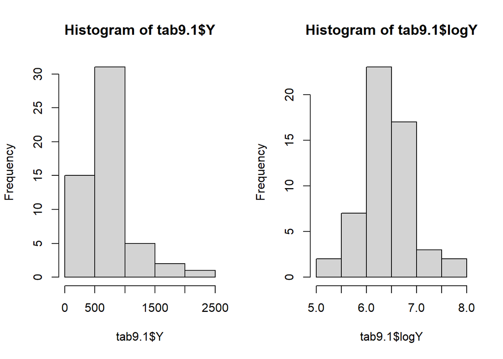

```r
par(mfrow=c(1,2))
hist(tab9.1$Y)
hist(tab9.1$logY)

library(ggplot2); library(GGally)
```

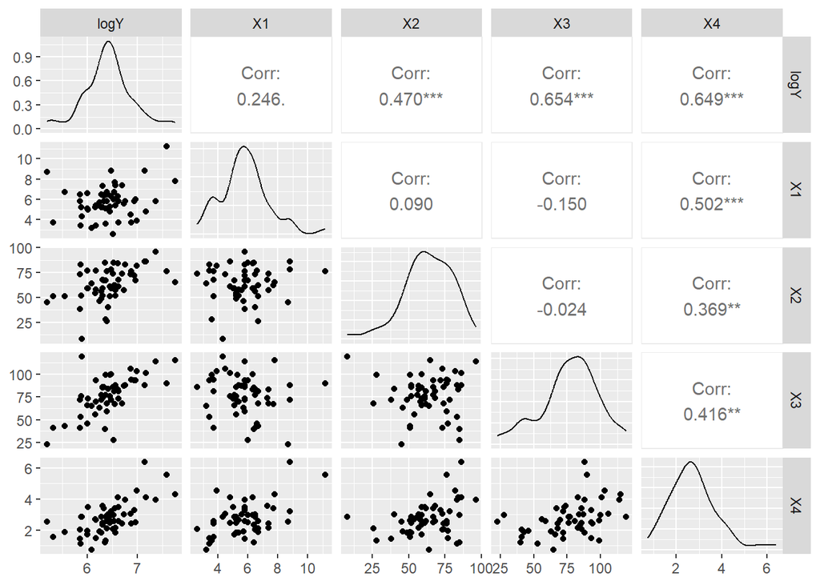

```r
ggpairs(tab9.1[,c('logY','X1','X2','X3','X4')])
```

## 2. 로그 변환 다중 선형회귀 모델

## 2. Log-Transformed Multiple Linear Regression Model

#### 2-1. logY~X1+X2+X3+X4

```r
reg1<-lm(logY~X1+X2+X3+X4, data=tab9.1)

summary(reg1)
```

```
##
## Call:
## lm(formula = logY ~ X1 + X2 + X3 + X4, data = tab9.1)
##
## Residuals:
##      Min       1Q   Median       3Q      Max
## -0.43500 -0.17591 -0.02091  0.18400  0.56192
##
## Coefficients:
##             Estimate Std. Error t value Pr(>|t|)
## (Intercept) 3.851948   0.266258  14.467  < 2e-16 ***
## X1          0.083684   0.028833   2.902  0.00554 **
## X2          0.012665   0.002315   5.471 1.51e-06 ***
## X3          0.015632   0.002100   7.443 1.37e-09 ***
## X4          0.032161   0.051465   0.625  0.53493
## ---
## Signif. codes:  0 '***' 0.001 '**' 0.01 '*' 0.05 '.' 0.1 ' ' 1
##
## Residual standard error: 0.2509 on 49 degrees of freedom
## Multiple R-squared:  0.7592, Adjusted R-squared:  0.7396
## F-statistic: 38.62 on 4 and 49 DF,  p-value: 1.388e-14
```

```r
summary(reg1)$r.squared
```

```
## [1] 0.7592108
```

```r
summary(reg1)$adj.r.squared
```

```
## [1] 0.7395546
```

#### 2-2. logY~X1+X2+X3

```r
reg2<-lm(logY~X1+X2+X3, data=tab9.1)

summary(reg2)
```

```
##
## Call:
## lm(formula = logY ~ X1 + X2 + X3, data = tab9.1)
##
## Residuals:
##      Min       1Q   Median       3Q      Max
## -0.46992 -0.17954 -0.03071  0.17883  0.59253
##
## Coefficients:
##             Estimate Std. Error t value Pr(>|t|)
## (Intercept) 3.766176   0.226758  16.609  < 2e-16 ***
## X1          0.095458   0.021692   4.401 5.67e-05 ***
## X2          0.013340   0.002035   6.556 2.97e-08 ***
## X3          0.016452   0.001630  10.094 1.17e-13 ***
## ---
## Signif. codes:  0 '***' 0.001 '**' 0.01 '*' 0.05 '.' 0.1 ' ' 1
##
## Residual standard error: 0.2493 on 50 degrees of freedom
## Multiple R-squared:  0.7573, Adjusted R-squared:  0.7427
## F-statistic:    52 on 3 and 50 DF,  p-value: 2.124e-15
```

```r
summary(reg2)$r.squared
```

```
## [1] 0.7572918
```

```r
summary(reg2)$adj.r.squared
```

```
## [1] 0.7427294
```

- 두 모델의 R-squared 및 Adjusted R-squared 값이 거의 유사
- 즉, X4가 포함된 reg1과 X4를 제외한 reg2 모델 간에는 설명력의 큰 차이가 없음
- X4는 모델의 성능 향상에 큰 기여를 하지 않는 변수

## 3. 통계적 평가지표(statistical criterion)

#### 3-1. AIC(Akaike Information Criterion)

- 모델의 적합도와 모델 복잡성을 모두 고려
- 복잡도 패널티: $2k$
- 과적합 방지, 값이 작을수록 긍정적
  $$\text{AIC} = -2 \cdot \log(\text{likelihood}) + 2k$$
- $k$: 모델의 자유도(추정 파라미터 수)

#### 3-2. BIC(Bayesian Information Criterion)

- AIC와 유사하나 모델 복잡성에 엄격(큰 표본일수록 단순 모델 선호)
- 복잡도 패널티: $k⋅log(n)$
- 포함관계가 없어도 모델 비교 가능, 값이 작을수록 긍정적
  $$\text{BIC} = -2 \cdot \log(\text{likelihood}) + k \cdot \log(n)$$
- $n$: 표본 크기
- $k$: 모델의 자유도

#### 3-3. PRESS(Prediction Sum of Squares)

- 각 관측치를 제외하고 모델을 적합(fit)한 뒤, 제외한 관측치에 대한 예측오차를 제곱한 합계
- 회귀 모델의 교차검증 성격을 가진 지표로, 모델의 일반화 능력을 평가
- 포함관계가 없어도 모델 비교 가능,값이 작을수록 긍정적
  $$\text{PRESS} = \sum_{i=1}^{n} \left( y_i - \hat{y}_{i(-i)} \right)^2$$
- $y_i$: 실제 관측값
- $\hat{y}_{i(-i)}$: $i$번째 관측치를 제외하고 적합한 모델로 예측한 값
- $n$: 관측치 수

#### 3-4. 요약

- AIC, BIC: 기존 데이터에 대한 적합도 + 복잡도
- PRESS: 새로운 데이터에서의 오차 추정(정확도)

```r
#AIC
extractAIC(reg1)
```

```
## [1]    5.0000 -144.5895
```

```r
extractAIC(reg2)
```

```
## [1]    4.0000 -146.1609
```

```r
#BIC
extractAIC(reg1, k = log(dim(tab9.1)[1]))
```

```
## [1]    5.0000 -134.6446
```

```r
extractAIC(reg2, k = log(dim(tab9.1)[1]))
```

```
## [1]    4.0000 -138.2049
```

```r
#PRESS
sum((reg1$residuals/(1-hatvalues(reg1)))^2)
```

```
## [1] 4.068573
```

```r
sum((reg2$residuals/(1-hatvalues(reg2)))^2)
```

```
## [1] 3.91424
```

- reg2일때 성능이 더 좋게 나옴

## 4. CP 통계량을 사용하여 최적의 변수 조합 찾기

```r
library(leaps)

X<-cbind(1, tab9.1$X1, tab9.1$X2, tab9.1$X3, tab9.1$X4)
logY<-tab9.1$logY

outs <- leaps(X, logY, int = FALSE, method="Cp")
head(outs$which)
```

```
##       1     2     3     4     5
## 1  TRUE FALSE FALSE FALSE FALSE
## 1 FALSE FALSE FALSE  TRUE FALSE
## 1 FALSE FALSE  TRUE FALSE FALSE
## 1 FALSE  TRUE FALSE FALSE FALSE
## 1 FALSE FALSE FALSE FALSE  TRUE
## 2  TRUE FALSE FALSE  TRUE FALSE
```

```r
head(outs$Cp)
```

```
## [1]  151.49752 1714.33991 1848.16528 2300.55274 3576.42469   66.48886
```

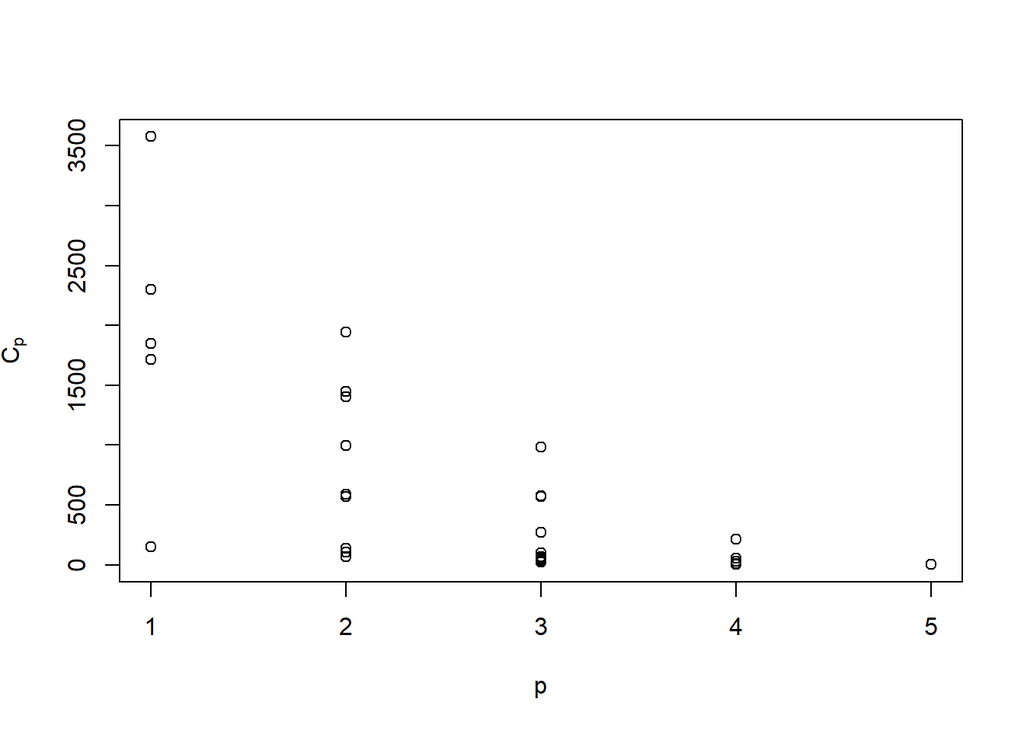

```r
plot(outs$size, outs$Cp, xlab = "p", ylab = expression(C[p]))
```

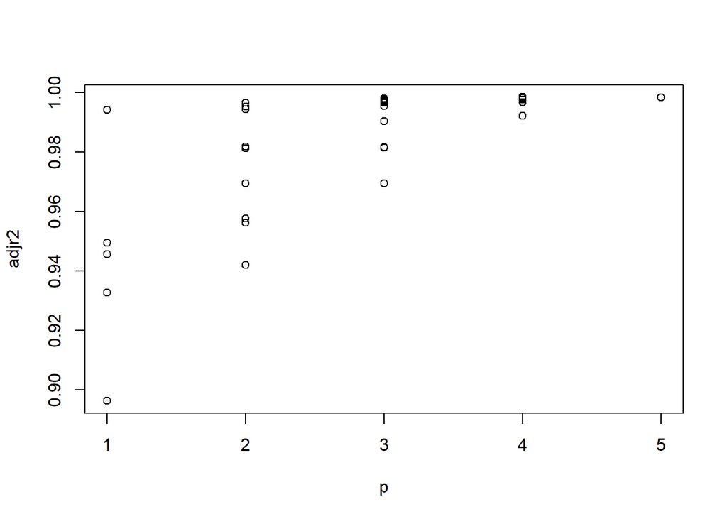

```r
# 독립 변수의 수(p)에 따른 조정된 결정 계수의 변화
outs <- leaps(X, logY, int = FALSE, method="adjr2")
plot(outs$size, outs$adjr2,  xlab = "p", ylab = "adjr2")
```

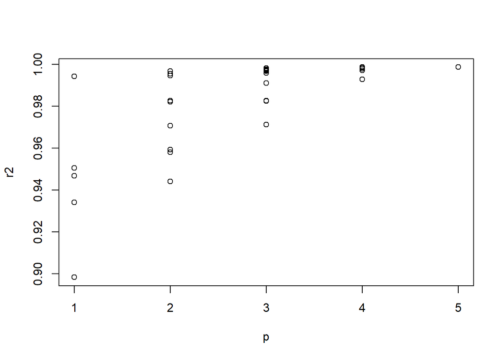

```r
# 독립 변수의 수(p)에 따른 단순한 결정 계수의 변화
outs <- leaps(X, logY, int = FALSE, method="r2")
plot(outs$size, outs$r2,    xlab = "p", ylab = "r2")
```

```r
# 가장 작은 CP 값을 찾습니다.
min_cp <- min(outs$Cp)

# 가장 작은 CP 값이 속한 인덱스를 찾습니다.
best_index <- which(outs$Cp == min_cp)

# 이 인덱스를 사용하여 변수 선택의 수를 결정합니다.
best_num_variables <- outs$size[best_index]
```

[output not shown]

## 5. 부분 데이터에 대한 회귀분석

#### 5-1. 데이터 분할

```r
X<-tab9.1[,1:8]
head(X)
```

```
##    X1 X2  X3   X4 X5 X6 X7 X8
## 1 6.7 62  81 2.59 50  0  1  0
## 2 5.1 59  66 1.70 39  0  0  0
## 3 7.4 57  83 2.16 55  0  0  0
## 4 6.5 73  41 2.01 48  0  0  0
## 5 7.8 65 115 4.30 45  0  0  1
## 6 5.8 38  72 1.42 65  1  1  0
```

```r
subset<-regsubsets(X, logY,nbest=1)
```

#### 5-2. 선택된 변수 조합

```r
summary(subset)$which
```

```
##   (Intercept)    X1    X2   X3    X4    X5    X6    X7    X8
## 1        TRUE FALSE FALSE TRUE FALSE FALSE FALSE FALSE FALSE
## 2        TRUE FALSE  TRUE TRUE FALSE FALSE FALSE FALSE FALSE
## 3        TRUE FALSE  TRUE TRUE FALSE FALSE FALSE FALSE  TRUE
## 4        TRUE  TRUE  TRUE TRUE FALSE FALSE FALSE FALSE  TRUE
## 5        TRUE  TRUE  TRUE TRUE FALSE FALSE  TRUE FALSE  TRUE
## 6        TRUE  TRUE  TRUE TRUE FALSE  TRUE  TRUE FALSE  TRUE
## 7        TRUE  TRUE  TRUE TRUE FALSE  TRUE  TRUE  TRUE  TRUE
## 8        TRUE  TRUE  TRUE TRUE  TRUE  TRUE  TRUE  TRUE  TRUE
```

- TRUE인 부분이 선택된 부분으로 제안된 조합은 8가지
- 1. Y ~ X3
- 2. Y ~ X2 + X3
- 3. Y ~ X2 + X3 + X8
- 4. Y ~ X1 + X2 + X3 + X8
- 5. Y ~ X1 + X2 + X3 + X6 + X8
- 6. Y ~ X1 + X2 + X3 + X5 + X6 + X8
- 7. Y ~ X1 + X2 + X3 + X5 + X6 + X7 + X8
- 8. Y ~ X1 + X2 + X3 + X4 + X5 + X6 + X7 + X8

#### 5-3. 결정계수 R²

```r
summary(subset)$rsq
```

```
## [1] 0.4275662 0.6632899 0.7780337 0.8298840 0.8374413 0.8434363 0.8460279
## [8] 0.8461286
```

- 변수 개수가 늘어날수록 R²는 점진적으로 증가
- 최대값은 0.8461로 약 85%의 설명력을 가짐

#### 5-4. 잔차제곱합 RSS

```r
summary(subset)$rss
```

```
## [1] 7.331575 4.312491 2.842883 2.178799 2.082008 2.005225 1.972032 1.970742
```

- 변수 개수가 늘어날수록 RSS는 점진적으로 감소 (적합도가 개선됨)
- 그러나 감소 폭은 점점 줄어듦 → 추가 변수가 주는 개선 효과는 점점 작아짐

#### 5-5. Mallows’ Cp 과적합 평가

```r
summary(subset)$cp
```

```
## [1] 117.409441  50.471575  18.914496   5.750774   5.540639   5.787389   7.029455
## [8]   9.000000
```

```r
summary(subset)$bic
```

```
## [1] -22.14638 -46.81382 -65.32647 -75.70392 -74.16875 -72.20888 -69.12126
## [8] -65.16761
```

- 변수를 4개까지 추가했을 때 성능이 개선되고, 변수 4개인 모델에서 최소값 -75.70을 가진 이후에는 변수를 추가할수록 오히려 BIC가 증가하여 과적합 가능성이 높아짐

#### 5-7. 후진 제거법으로 최적 변수 조합 선택

```r
library(MASS)
step <- step(reg1, direction="backward")
```

```
## Start:  AIC=-144.59
## logY ~ X1 + X2 + X3 + X4
##
##        Df Sum of Sq    RSS     AIC
## - X4    1    0.0246 3.1085 -146.16
## <none>              3.0840 -144.59
## - X1    1    0.5302 3.6141 -138.02
## - X2    1    1.8839 4.9678 -120.84
## - X3    1    3.4862 6.5702 -105.75
##
## Step:  AIC=-146.16
## logY ~ X1 + X2 + X3
##
##        Df Sum of Sq    RSS      AIC
## <none>              3.1085 -146.161
## - X1    1    1.2040 4.3125 -130.483
## - X2    1    2.6724 5.7810 -114.658
## - X3    1    6.3341 9.4427  -88.162
```

## 6. model test

#### 6-1. 테스트 데이터 로드

```r
test<-read.table("http://www.stat.ufl.edu/~rrandles/sta4210/Rclassnotes/data/textdatasets/KutnerData/Chapter%20%209%20Data%20Sets/CH09TA05.txt")
names(test)<-c("X1","X2","X3","X4","X5","X6","X7","X8","Y","logY")
head(test)
```

```
##    X1 X2 X3   X4 X5 X6 X7 X8   Y  logY
## 1 7.1 23 78 1.93 45  0  1  0 302 5.710
## 2 4.9 66 91 3.05 34  1  0  0 767 6.642
## 3 6.4 90 35 1.06 39  1  0  1 487 6.188
## 4 5.7 35 70 2.13 68  1  0  0 242 5.489
## 5 6.1 42 69 2.25 70  0  0  1 705 6.558
## 6 8.0 27 83 2.03 35  1  1  0 716 6.574
```

```r
dim(test)
```

```
## [1] 54 10
```

#### 6-2. 훈련 데이터의 잔차제곱평균 계산(MSE on Training Data)

```r
reg1<-lm(logY~X1+X2+X3+X8, data=tab9.1)
reg2<-lm(logY~X1+X2+X3+X6+X8, data=tab9.1)
reg3<-lm(logY~X1+X2+X3+X5+X6+X8,data=tab9.1)


MSE1<- sum((tab9.1$logY-predict(reg1, newdata=tab9.1))^2)/(54-5)
MSE2<- sum((tab9.1$logY-predict(reg2, newdata=tab9.1))^2)/(54-6)
MSE3<- sum((tab9.1$logY-predict(reg3, newdata=tab9.1))^2)/(54-7)

MSE1;MSE2;MSE3
```

```
## [1] 0.04446529
```

```
## [1] 0.04337516
```

```
## [1] 0.04266437
```

- 훈련 데이터 MSE: 모델 적합도 평가
- 모델이 복잡해질수록 MSE가 약간씩 감소

#### 6-3. 테스트 데이터의 잔차제곱평균 계산(MSE on Test Data)

```r
reg1.new<-lm(logY~X1+X2+X3+X8, data=test)
reg2.new<-lm(logY~X1+X2+X3+X6+X8, data=test)
reg3.new<-lm(logY~X1+X2+X3+X5+X6+X8, data=test)


MSPR1<- sum((test$logY-predict(reg1, newdata=test))^2)/54
MSPR2<- sum((test$logY-predict(reg2, newdata=test))^2)/54
MSPR3<- sum((test$logY-predict(reg3, newdata=test))^2)/54

MSPR1; MSPR2; MSPR3
```

```
## [1] 0.07731876
```

```
## [1] 0.0764202
```

```
## [1] 0.07941142
```

- 테스트 데이터 MSE: 모델 예측력 평가
- 가장 단순한 모델과 두번째 모델은 성능이 비슷하고, 가장 복잡한 모델의 MSE가 가장 높음
- reg3은 적합도가 가장 크고, 예측력이 가장 낮으므로 과적합 가능성이 있음